# Assignemnt4-Practical Machine Learning Course

Guillaume Polet

11/09/2018

## Introduction

### Background

Using devices such as Jawbone Up, Nike FuelBand, and Fitbit it is now possible to collect a large amount of data about personal activity relatively inexpensively. These type of devices are part of the quantified self movement – a group of enthusiasts who take measurements about themselves regularly to improve their health, to find patterns in their behavior, or because they are tech geeks. One thing that people regularly do is quantify how much of a particular activity they do, but they rarely quantify how well they do it. In this project, your goal will be to use data from accelerometers on the belt, forearm, arm, and dumbell of 6 participants. They were asked to perform barbell lifts correctly and incorrectly in 5 different ways:

- Exactly according to the specification (Class A)
- Throwing the elbows to the front (Class B) - mistake
- Lifting the dumbbell only halfway (Class C) - mistake
- Lowering the dumbbell only halfway (Class D) - mistake
- Throwing the hips to the front (Class E) - mistake

Accelerometers were located on:

### Goal

Create a report describing:

- how you built your model,
- how you used cross validation
- what you think the expected out of sample error is
- why you made the choices you did

## Getting and Loading the Data

## Preparing The Data

### Loading the packages and the data

```r
if(require(xgboost)==FALSE)(install.packages("xgboost")); library(xgboost)
if(require(knitr)==FALSE)(install.packages("knitr")); library(knitr)
if(require(randomForest)==FALSE)(install.packages("randomForest")); library(randomForest)
if(require(caret)==FALSE)(install.packages("caret")); library(caret)
if(require(dplyr)==FALSE)(install.packages("dplyr")); library(dplyr)

set.seed(12345)

trainingUrl <- "http://d396qusza40orc.cloudfront.net/predmachlearn/pml-training.csv"
testingUrl <- "http://d396qusza40orc.cloudfront.net/predmachlearn/pml-testing.csv"

training <- read.csv(url(trainingUrl), na.strings=c("NA","#DIV/0!",""))
testing <- read.csv(url(testingUrl), na.strings=c("NA","#DIV/0!",""))

print(dim(training))
```

```
## [1] 19622   160
```

As we can see there are 160 features in the dataset

### Cleaning the data

```r
#Remove factors with less than 2 levels;
training<-training[, sapply(training, function(col) length(unique(col))) > 1]

#remove variales with more than 0.7 percent of missing

training<-training[, -which(colMeans(is.na(training)) > 0.85)]

#Let's also remove the variablew that are not predictors
training<-training[,-(1:7)]

# Remove variables with a near zero variance
nzv <- nearZeroVar(training, saveMetrics=TRUE)
training <- training[,nzv$nzv==FALSE]

# Removing highly correlated variables
#High Correlation
nums <- sapply(training, is.numeric)
cornums<-training[complete.cases(training),nums]
corr<-cor(cornums)
# highCorr <- sum(abs(corr[upper.tri(corr)]) > .96)

hc<-findCorrelation(corr, cutoff = 0.98,names=TRUE, verbose = TRUE)
```

```
## Compare row 10  and column  1 with corr  0.992
##   Means:  0.27 vs 0.168 so flagging column 10
## Compare row 1  and column  4 with corr  0.981
##   Means:  0.25 vs 0.164 so flagging column 1
## All correlations <= 0.98
```

```r
hc
```

```
## [1] "accel_belt_z" "roll_belt"
```

```r
#Remove highly correlated variables
training<-training[,!(names(training) %in% hc)]

print(dim(training))
```

```
## [1] 19622    51
```

The cleaning of the data results in having 51 variables

## Building the Model

### RandomForest

To build the model we will use the RandomForest as it is one of the most powerful classifier.

#### Partitioning the data in two sets and taking care of the target variable

```r
# Preparing the target variable for the model
classe <- training$classe
df <- select(training, -classe)

#Partition the data set into the training and test set
trainIndex <- createDataPartition(classe, p=.8, list = FALSE)
dfTrain <- df[ trainIndex, ]
dfTest <- df[-trainIndex, ]
```

#### Model building with cross validation

The crossvalidation is done with the function ** trainControl ** and we will use a k=5 allow parallelisation since the size of the data set is quite big.

```r
#Setting the control parameters (cross validation)
trControl <- trainControl(method = "cv",
                          number = 5,
                          verboseIter = TRUE,
                          allowParallel = TRUE,
                          summaryFunction = multiClassSummary)

#Train the model
if (!file.exists("randomForestAssignment4.RData")) {
  rf<- caret::train(x = dfTrain,
                       y = classe[trainIndex],
                       method = 'rf',
                       metric = "Accuracy",
                       trControl = trControl,
                      preProcess=c("center", "scale"))
  save(rf, file = "randomForestAssignment4.RData")
} else {
    # Use cached model
    load(file = "randomForestAssignment4.RData")
}


# model Summary
rf
```

```
## Random Forest
##
## 15699 samples
##    50 predictor
##     5 classes: 'A', 'B', 'C', 'D', 'E'
##
## Pre-processing: centered (50), scaled (50)
## Resampling: Cross-Validated (5 fold)
## Summary of sample sizes: 12559, 12560, 12559, 12561, 12557
## Resampling results across tuning parameters:
##
##   mtry  Accuracy   Kappa      Mean_F1    Mean_Sensitivity
##    2    0.9919743  0.9898465  0.9912288  0.9908479
##   26    0.9927390  0.9908141  0.9921748  0.9918893
##   50    0.9887898  0.9858182  0.9880574  0.9877920
##   Mean_Specificity  Mean_Pos_Pred_Value  Mean_Neg_Pred_Value
##   0.9979918         0.9916936            0.9980532
##   0.9981756         0.9925053            0.9982280
##   0.9971886         0.9883819            0.9972391
##   Mean_Detection_Rate  Mean_Balanced_Accuracy
##   0.1983949            0.9944198
##   0.1985478            0.9950324
##   0.1977580            0.9924903
##
## Accuracy was used to select the optimal model using  the largest value.
## The final value used for the model was mtry = 26.
```

As we can see, on the training set the accuracy is really high since it’s more than 99%!

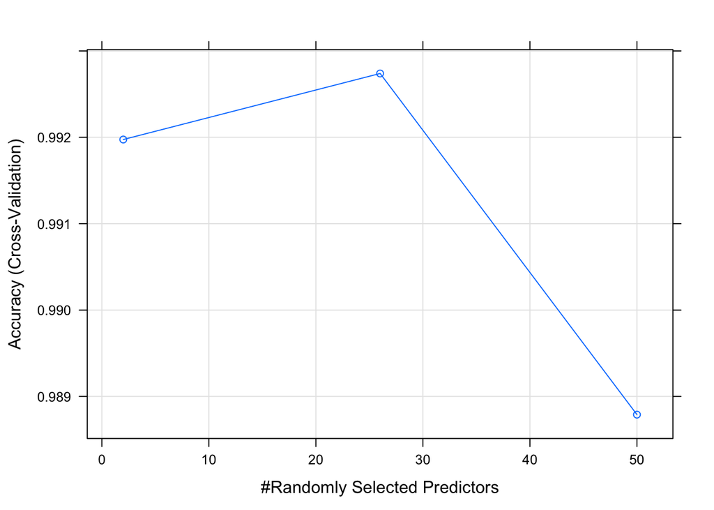

```r
plot(rf)
```

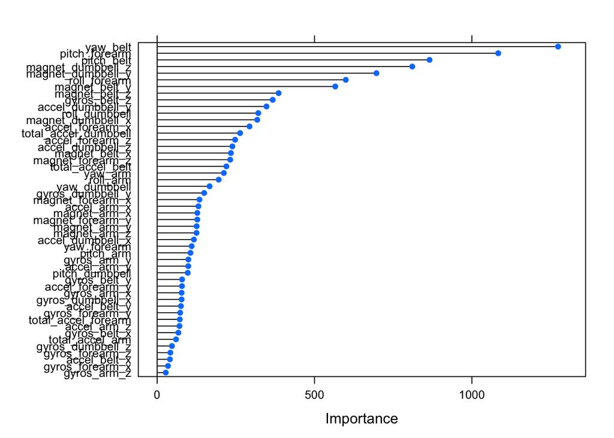

```r
rfImp <- varImp(rf, scale = FALSE)
plot(rfImp)
```

#### Prediction and evaluation on the test set

```r
  predTest<- predict(rf,dfTest)
  cm<-confusionMatrix(predTest,classe[-trainIndex])
  print(cm)
```

```
## Confusion Matrix and Statistics
##
##           Reference
## Prediction    A    B    C    D    E
##          A 1114    6    0    0    0
##          B    2  753    7    0    0
##          C    0    0  677    6    0
##          D    0    0    0  636    1
##          E    0    0    0    1  720
##
## Overall Statistics
##
##                Accuracy : 0.9941
##                  95% CI : (0.9912, 0.9963)
##     No Information Rate : 0.2845
##     P-Value [Acc > NIR] : < 2.2e-16
##
##                   Kappa : 0.9926
##  Mcnemar's Test P-Value : NA
##
## Statistics by Class:
##
##                      Class: A Class: B Class: C Class: D Class: E
## Sensitivity            0.9982   0.9921   0.9898   0.9891   0.9986
## Specificity            0.9979   0.9972   0.9981   0.9997   0.9997
## Pos Pred Value         0.9946   0.9882   0.9912   0.9984   0.9986
## Neg Pred Value         0.9993   0.9981   0.9978   0.9979   0.9997
## Prevalence             0.2845   0.1935   0.1744   0.1639   0.1838
## Detection Rate         0.2840   0.1919   0.1726   0.1621   0.1835
## Detection Prevalence   0.2855   0.1942   0.1741   0.1624   0.1838
## Balanced Accuracy      0.9980   0.9946   0.9940   0.9944   0.9992
```

As we can see the accuracy is quite stable hence our model does still predict well on new data! It doesn’t suffer from overfitting.

#### Final Model

```r
rf$finalModel
```

```
##
## Call:
##  randomForest(x = x, y = y, mtry = param$mtry)
##                Type of random forest: classification
##                      Number of trees: 500
## No. of variables tried at each split: 26
##
##         OOB estimate of  error rate: 0.54%
## Confusion matrix:
##      A    B    C    D    E class.error
## A 4461    1    1    0    1 0.000672043
## B   20 3009    8    0    1 0.009545754
## C    0    9 2720    9    0 0.006574142
## D    0    1   20 2549    3 0.009327633
## E    0    0    4    7 2875 0.003811504
```

### Validation with the quiz

#### Recreating the same features for validation

```r
testing<-testing[,(names(testing) %in% names(training))]
```

#### Predicting

```r
print(predict(rf, newdata=testing))
```

```
##  [1] B A B A A E D B A A B C B A E E A B B B
## Levels: A B C D E
```